# Simple Random Walk

Andrew Kerr

2023-04-06

```r
library(tidyverse)
```

Two equally matched opponents are competing in a game in which changes in score occur often and in one point increments. (Imagine a basketball game in which every basket counts only one point.) We’ll use simulation to investigate the following questions.

- Which is more likely: that one team leads for most of the game, or that the lead tends to change frequently over the course of the game?
- When would you expect the largest lead (or deficit) to occur — near the beginning, the end, or in the middle of the game? (If the largest lead (or deficit) is attained at several points in the game, when you do expect it to first occur?)
- When would you expect the last tie to occur — near the beginning, the end, or in the middle of the game?

Pause to think about these questions before proceeding.

Let Xn be the point difference (team A - team B) after the first scores; Xn > 0 if team A is in the lead, Xn < 0 if team B is in the lead, and Xn = 0if the score is tied. We can model Xn as a simple symmetric random walk on the integers starting from X0 = 0, like in the Harry and Tom example from the handout.

Consider the first 2n steps of the walk. We say 2n because that will be even. We are interested, in particular, in times at which the walk can be in state 0 (that is, the score is tied), which can only happen in an even number of steps.

We are interested in the following random variables, each of which has been scaled to take values between 0 and 1.

- T/(2n), where T is the time, between 0 and 2n, at which the walk is last in state 0. For example, if n = 50 and the walk takes 100 steps, and it is last at 0 at step 84, then T/(2n) = 0.84 (the last tie occurs with 16% of the game remaining.)
- L/(2n), the fraction of time the walk stays above 0, where L the number of time steps for which the walk is above 0; L/(2n) is the proportion of the game team A is in the lead.
- M/(2n), where M is the first time, between 0 and 2n, at which the maximum value, over time 0 to 2n, of the walk is attained; M/(2n) is the first time (measured as a proportion of the full game) at which team A’s largest lead is attained.

Write your own code to conduct and run a simulation to approximate the distribution of each of T/(2n), L/(2n), and M/(2n) for n = 100. Summarize the results with appropriate plots and summary statistics, and describe the distributions. Consider the three questions at the start of this page; what do your simulation results suggest? Write a brief report summarizing your results and conclusions.

Optional: experiment with different values of n and discuss how the results change with n.

# Random Walk Function

```r
random_walk <- function(sim_count, n, T_plt, L_plt, M_plt){
  n_sims <- sim_count
  n <- n

  results <- matrix(NA,
                    nrow = n_sims,
                    ncol = 3,
                    dimnames = list(c(), c("T", "L", "M")))
  sims <- data.frame(time = 0:(2*n))

  for(i in 1:n_sims){
    N <- 0:(2*n)
    X <- rbinom((2*n), 1, 0.5)
    X <- replace(X, X == 0, -1)
    X <- c(0, X)
    Xn <- cumsum(X)

    sim <- data.frame(N = N, X = X, Xn = Xn)

    T <- sim %>%
      filter(Xn == 0) %>%
      summarise(max(N))

    L <- sim %>%
      filter(Xn > 0) %>%
      count()

    M <- sim %>%
      slice_max(Xn, with_ties = FALSE) %>%
      select(N)

    sims[i+1] <- sim$Xn
    results[i,] <- c(as.double(T/(2*n)), as.double(L/(2*n)), as.double(M/(2*n)))
  }


  walks_10 <- sims[1:11] %>%
    pivot_longer(cols = !time, names_to = "walk", values_to = "score") %>%
    ggplot() +
    geom_line(aes(time, score, color = walk)) +
    theme_bw()

  plot(walks_10)

  if(T_plt) {
    hist(results[, 1], breaks = seq(0, 1, 0.05),
         main = paste("Last Tie N =", 2*n),
         xlab = "Proportion of Game Played Until Last Tie")
  }
  if(L_plt) {
    hist(results[, 2], breaks = seq(0, 1, 0.05),
         main = paste("Walk Lead N =", 2*n),
         xlab = "Proportion of Game Team A Led")
  }
  if(M_plt) {
    hist(results[, 3], breaks = seq(0, 1, 0.05),
         main = paste("First Time Max Lead N =", 2*n),
         xlab = "Proportion of Game Team A Attained Max Lead")
  }

  summary(results)
}
```

# Simulations

## N = 100

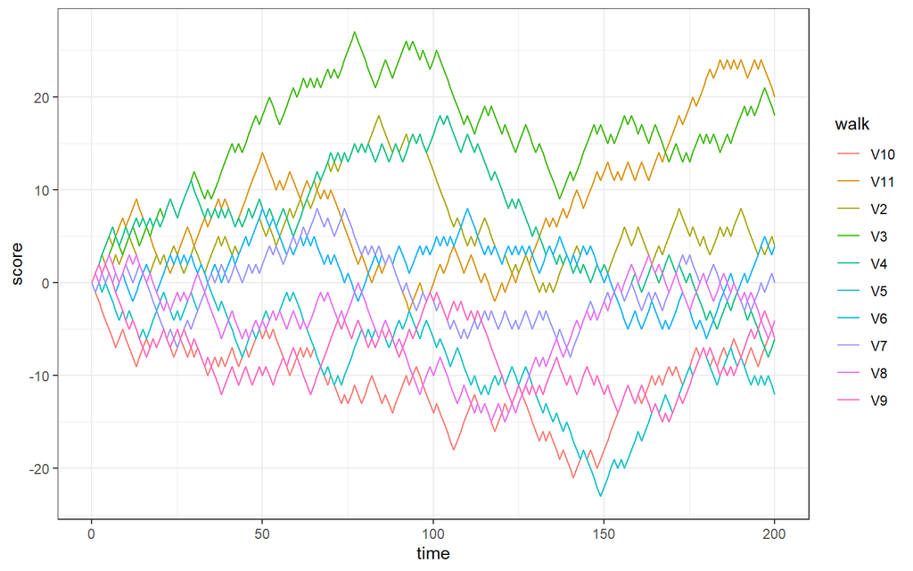

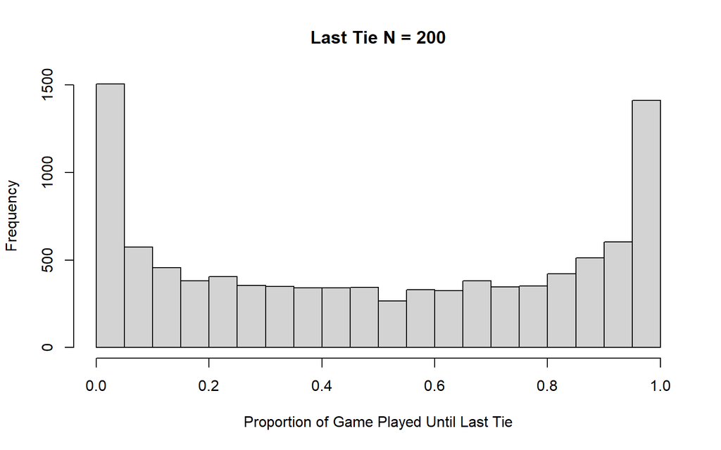

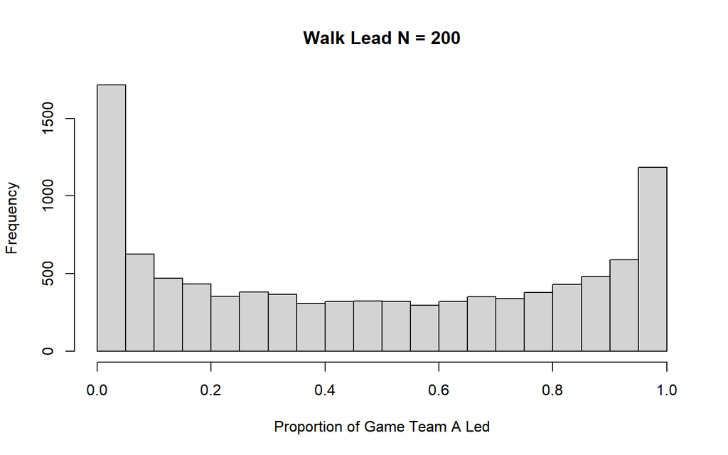

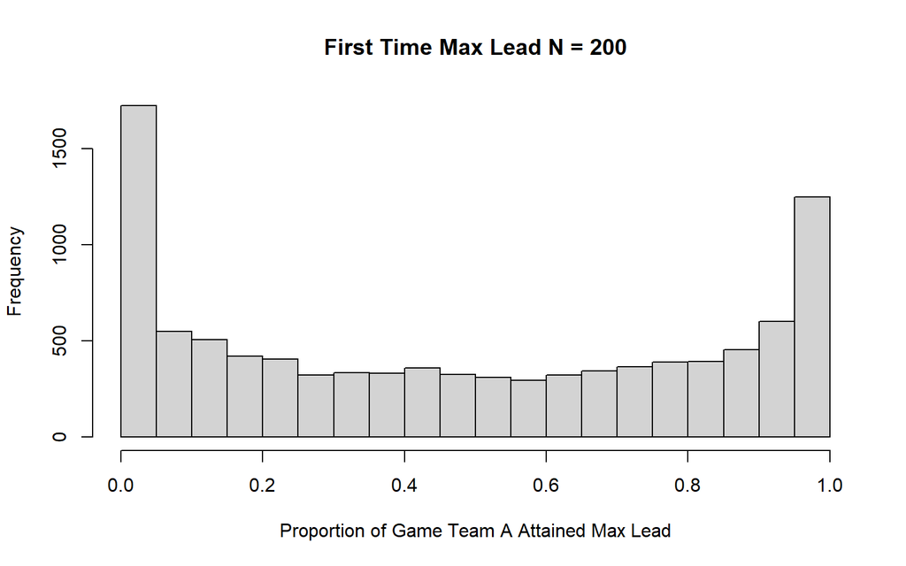

```
##        T               L                M
##  Min.   :0.000   Min.   :0.0000   Min.   :0.0000
##  1st Qu.:0.150   1st Qu.:0.1200   1st Qu.:0.1250
##  Median :0.500   Median :0.4550   Median :0.4600
##  Mean   :0.503   Mean   :0.4742   Mean   :0.4782
##  3rd Qu.:0.860   3rd Qu.:0.8250   3rd Qu.:0.8300
##  Max.   :1.000   Max.   :1.0000   Max.   :1.0000
```

```r
random_walk(10000, 100, TRUE, TRUE, TRUE)
```

## N = 10 v. N = 100 v. N = 500

### T/(2n)

```r
for(i in c(10, 100, 500)){
  random_walk(10000, i, TRUE, FALSE, FALSE)
}
```

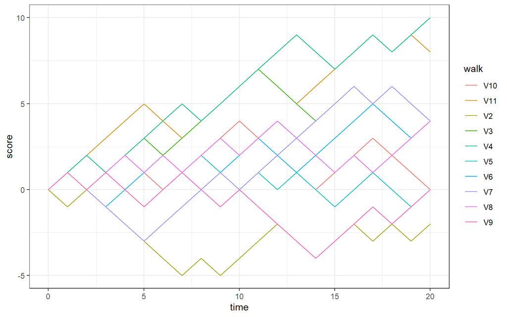

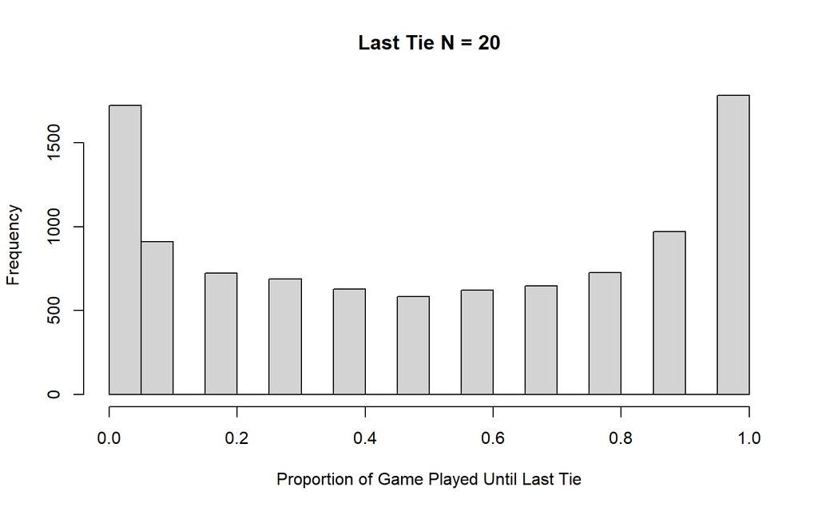

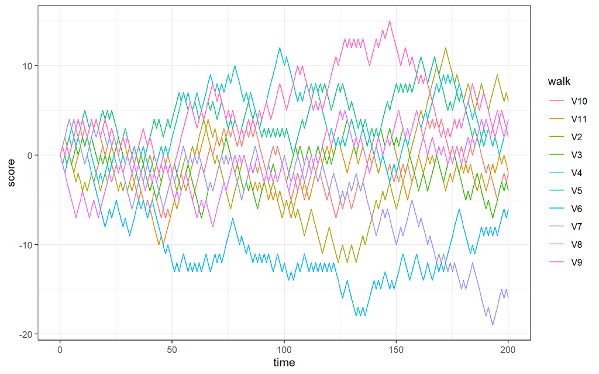

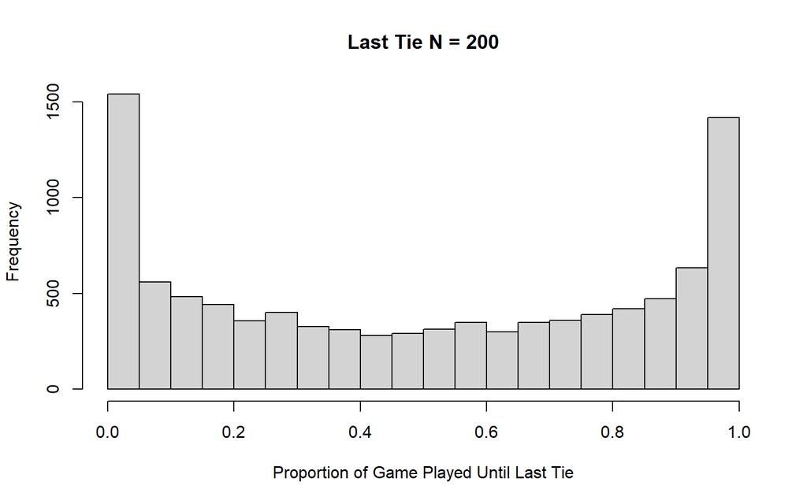

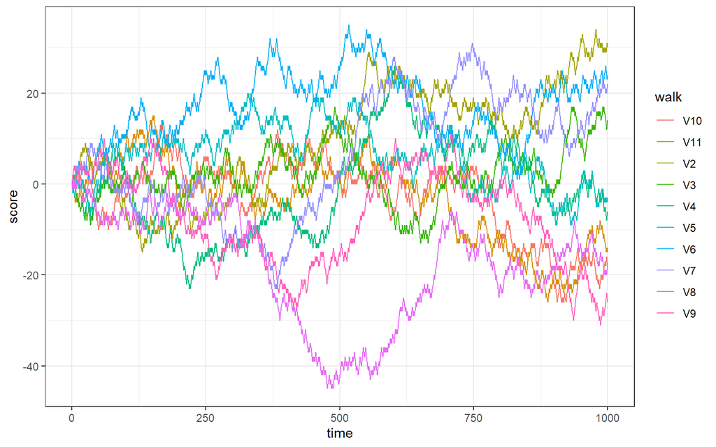

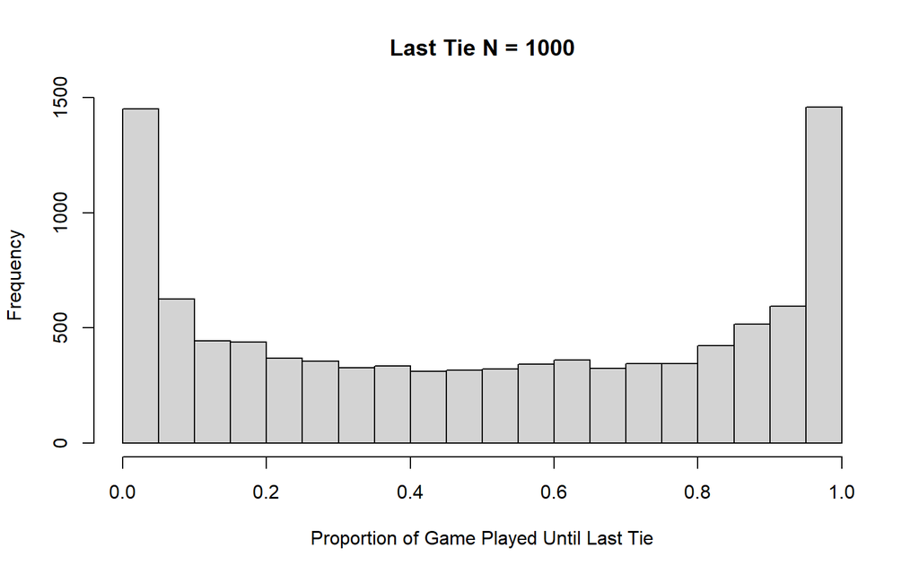

- As n increases, the middle of the distribution takes on a more uniform shape. However, at all three values of n the overall shape of the distribution is the same: large frequencies at 0 and 1 with a U-shape of frequencies in between.

### L/(2n)

```r
for(i in c(10, 100, 500)){
  random_walk(10000, i, FALSE, TRUE, FALSE)
}
```

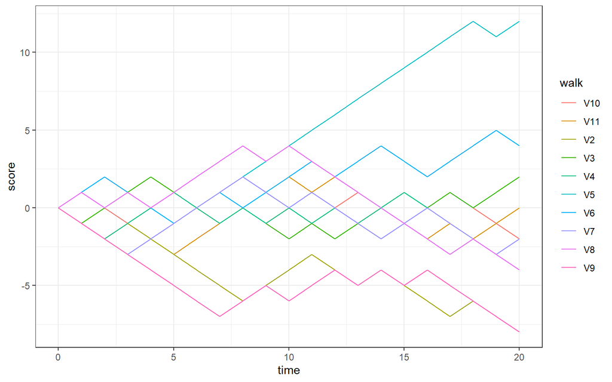

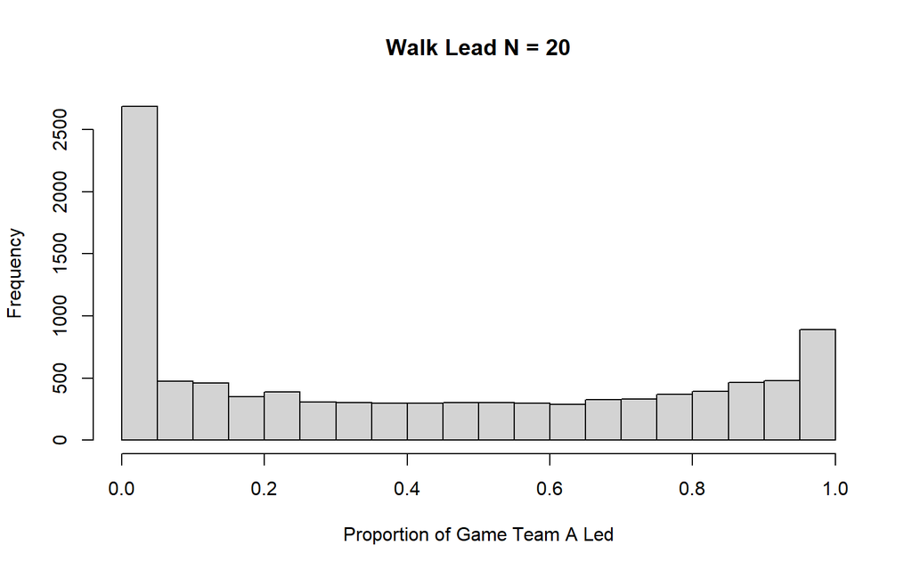

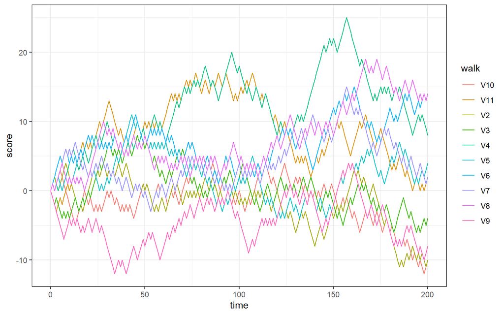

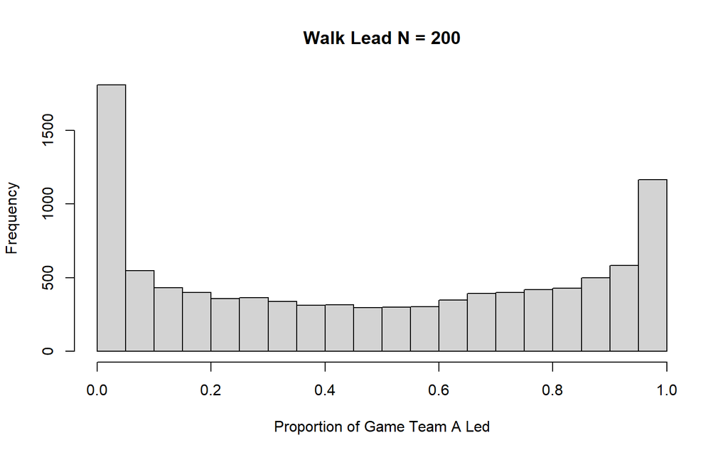

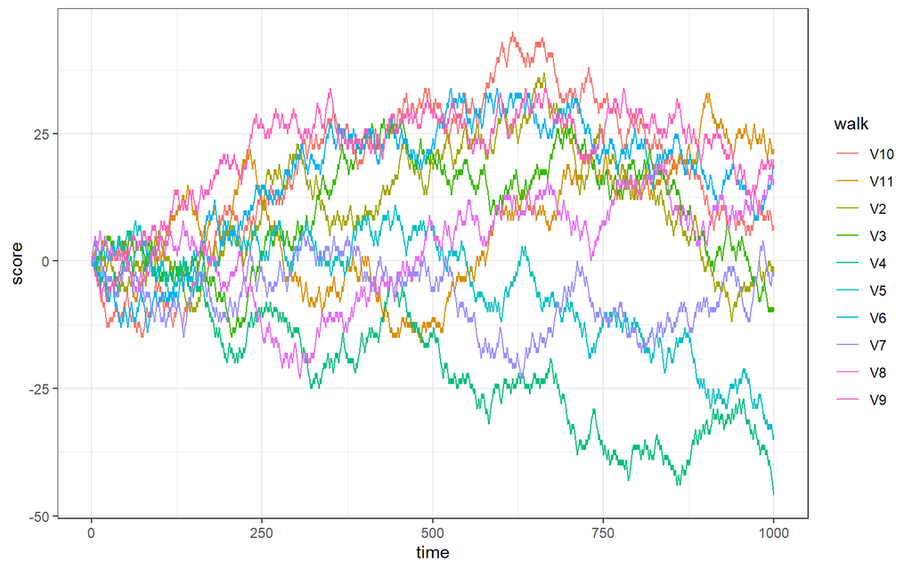

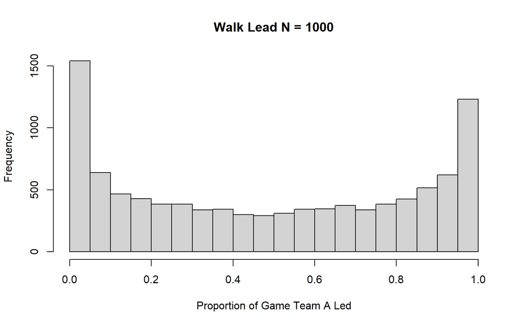

- As n increases, the frequency of 1 begins to catch up to the frequency at 0. Unlike T/(2n), the U-shape of large values of N is not present at N = 10. This suggests that in these simulations, most of the game was a tie or team B held the lead.

### M/(2n)

```r
for(i in c(10, 100, 500)){
  random_walk(10000, i, FALSE, FALSE, TRUE)
}
```

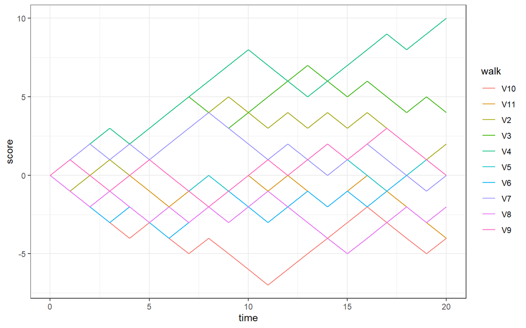

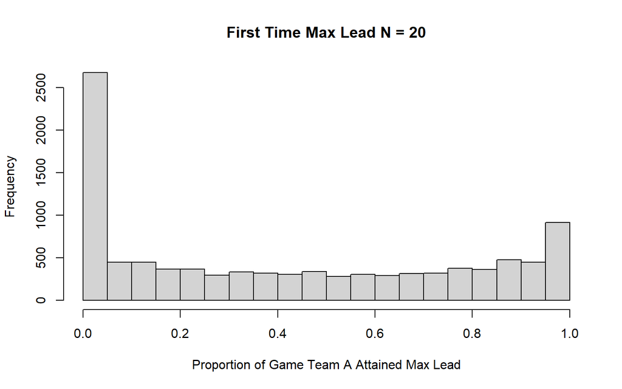

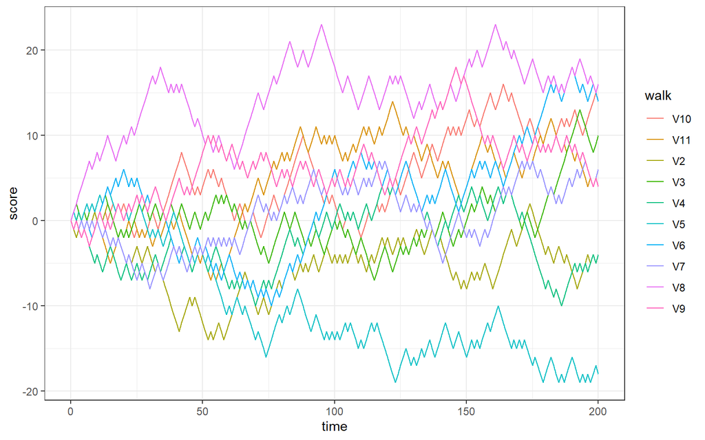

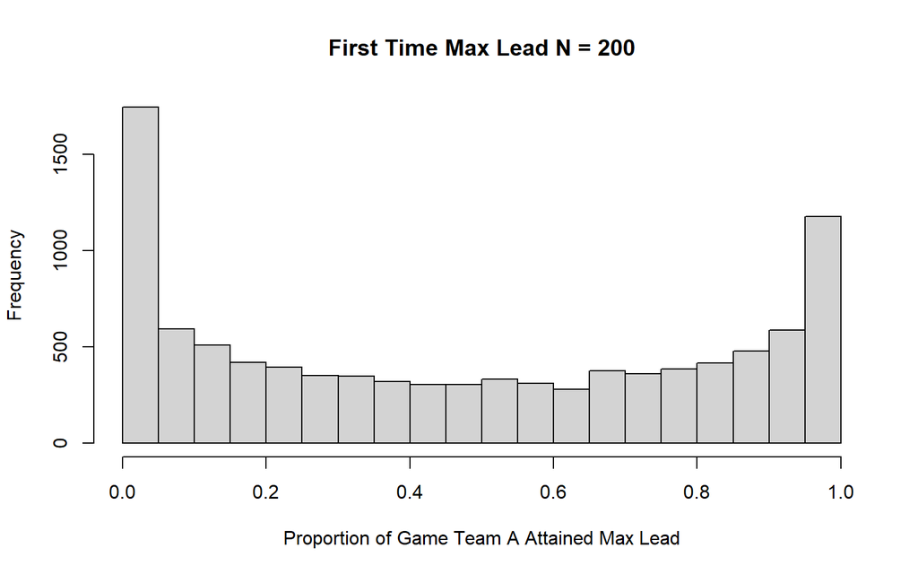

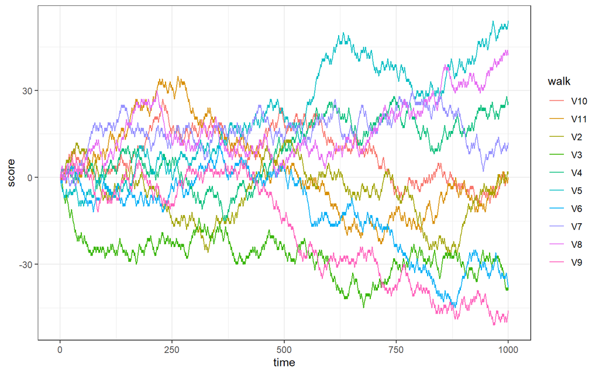

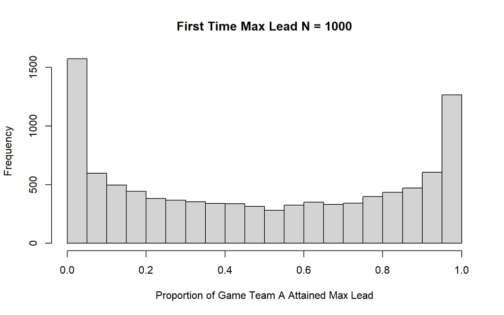

- As n increases, the frequency of 1 begins to catch up to the frequency at 0. As I noted in my results, L/(2n) and M/(2n) appear slightly more similar to each other than T/(2n) is. This is reflected in how low counts of n for L/(2n) and M/(2n) appear similar, with most proportions at 0, then 1, while the proportions for T/(2n) are roughly equal at 0 and 1 - even at low counts of n.